# **Ex 2**

Lior Belkin, 315818765.

Rachel Kucherenko

```python
!pip install Pillow
```

```python
from google.colab import files
uploaded = files.upload()
```

```
Saving Cliff_beach_BOEM_gov.jpg to Cliff_beach_BOEM_gov.jpg
```

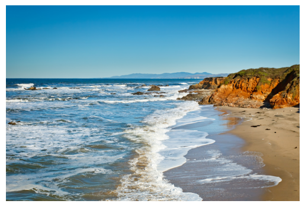

```python
from PIL import Image
import matplotlib.pyplot as plt

# Get the uploaded file name
file_name = list(uploaded.keys())[0]

# Open the image
image = Image.open(file_name)

# Display the image
plt.imshow(image)
plt.axis('off')  # Hide the axis
plt.show()
```

```python
# Get image dimensions
width, height = image.size

# Display the image dimensions
print(f"Image dimensions: {width} x {height} pixels")
```

```
Image dimensions: 2746 x 1830 pixels
```

B

First we will normalize the image

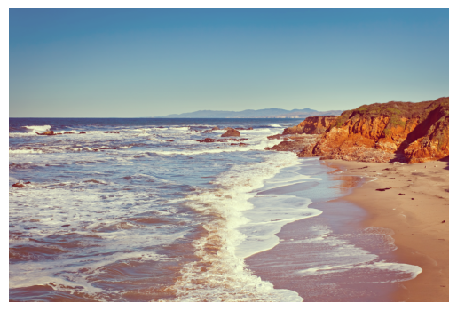

```python
# Summarize the color dimensions
import numpy as np

# Convert image to numpy array
image_array = np.array(image)

# Calculate mean and standard deviation for each color channel
mean = np.mean(image_array, axis=(0, 1))
std = np.std(image_array, axis=(0, 1))

# Normalize the image
normalized_image_array = (image_array - mean) / std

# Scale normalized array back to 0-255 range
normalized_image_array = ((normalized_image_array - np.min(normalized_image_array)) /
                          (np.max(normalized_image_array) - np.min(normalized_image_array)) * 255).astype(np.uint8)

# Convert back to image
normalized_image = Image.fromarray(normalized_image_array)

# Display the normalized image
plt.imshow(normalized_image)
plt.axis('off')  # Hide the axis
plt.show()
```

We see a change in the quality of the image (greater clarity)

Second, we will present the image in gray scale

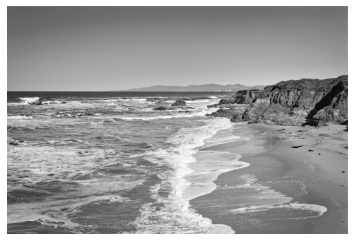

```python
# Convert the normalized image to grayscale
gray_image = normalized_image.convert('L')

# Display the grayscale image
plt.imshow(gray_image, cmap='gray')
plt.axis('off')  # Hide the axis
plt.show()
```

C

```
Number of singular values: 1830
```

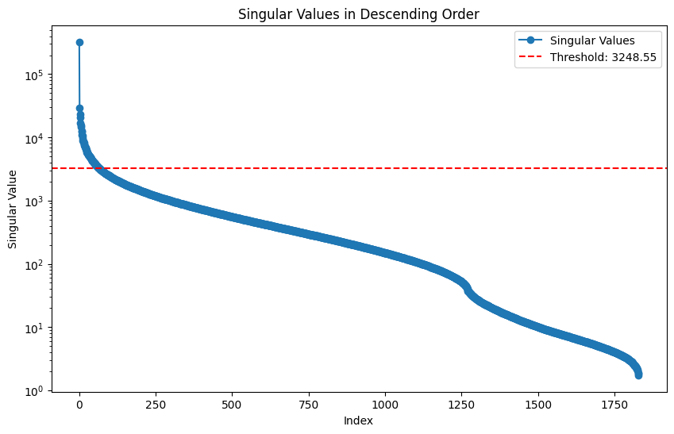

```
Number of singular values greater than 1% of the largest singular value: 66
```

```python
# Convert the image to grayscale
gray_image = image.convert('L')
gray_image_array = np.array(gray_image)

# Perform SVD decomposition
U, S, Vt = np.linalg.svd(gray_image_array)

# Number of singular values
num_singular_values = len(S)
print(f"Number of singular values: {num_singular_values}")

# Plot the singular values in descending order
plt.figure(figsize=(10, 6))
plt.plot(S, label='Singular Values', marker='o')

# Calculate the threshold for singular values greater than 1% of the largest singular value
threshold = 0.01 * np.max(S)
significant_singular_values = S[S > threshold]

# Add a dashed line at the threshold
plt.axhline(y=threshold, color='r', linestyle='--', label=f'Threshold: {threshold:.2f}')
plt.legend()
plt.title('Singular Values in Descending Order')
plt.xlabel('Index')
plt.ylabel('Singular Value')
plt.yscale('log')  # Use a logarithmic scale for better visualization of smaller values
plt.show()

# Number of singular values greater than 1% of the largest singular value
num_significant_singular_values = len(significant_singular_values)
print(f"Number of singular values greater than 1% of the largest singular value: {num_significant_singular_values}")
```

The number of singular values corresponds to the smaller dimension of the image. Therefore equal to 1830

Above the threshold line there are significant values that contribute more to the image than those below it.

D

```
Original image size: 5025180 bytes
Normalized image size: 40201440 bytes
```

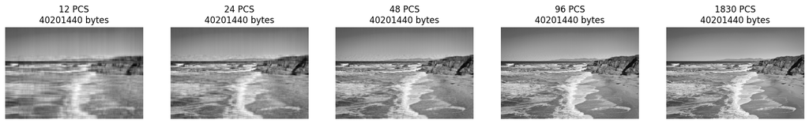

```python
import numpy as np
from PIL import Image
import matplotlib.pyplot as plt

# Convert the image to grayscale
gray_image = image.convert('L')
gray_image_array = np.array(gray_image)

# Perform SVD decomposition
U, S, Vt = np.linalg.svd(gray_image_array)

# Save the original image size in bytes
original_image_size_bytes = gray_image_array.nbytes
print(f"Original image size: {original_image_size_bytes} bytes")

# Normalize the image
normalized_image_array = (gray_image_array - np.mean(gray_image_array)) / np.std(gray_image_array)

# Save the normalized image size in bytes
normalized_image_size_bytes = normalized_image_array.nbytes
print(f"Normalized image size: {normalized_image_size_bytes} bytes")

# Define the different PCS values
pcs_values = [12, 24, 48, 96, len(S)]

# Function to restore image using k PCS
def restore_image(U, S, Vt, k):
    Uk = U[:, :k]
    Sk = np.diag(S[:k])
    Vtk = Vt[:k, :]
    restored_image_array = np.dot(Uk, np.dot(Sk, Vtk))
    return restored_image_array

# Plot the restored images
fig, axes = plt.subplots(1, len(pcs_values), figsize=(20, 6))
for ax, pcs in zip(axes, pcs_values):
    restored_image_array = restore_image(U, S, Vt, pcs)
    restored_image = Image.fromarray(np.clip(restored_image_array, 0, 255).astype(np.uint8))
    restored_image_size_bytes = restored_image_array.nbytes
    ax.imshow(restored_image, cmap='gray')
    ax.set_title(f'{pcs} PCS\n{restored_image_size_bytes} bytes')
    ax.axis('off')

plt.show()
```

We will see big differences between using 12 values for example and 1830 (the number of singular values), because 12 values capture only the most significant features of the image and ignore more subtle features, therefore creating a kind of "shadow" of reconstruction, while 1830 represents the information the full image.

```
Original image size: 5025180 bytes
Normalized image size: 40201440 bytes
```

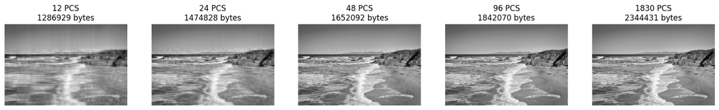

```python
import numpy as np
from PIL import Image
import matplotlib.pyplot as plt
import os
import tempfile

# Convert the image to grayscale
gray_image = image.convert('L')
gray_image_array = np.array(gray_image)

# Perform SVD decomposition
U, S, Vt = np.linalg.svd(gray_image_array)

# Save the original image size in bytes
original_image_size_bytes = gray_image_array.nbytes
print(f"Original image size: {original_image_size_bytes} bytes")

# Normalize the image
normalized_image_array = (gray_image_array - np.mean(gray_image_array)) / np.std(gray_image_array)

# Save the normalized image size in bytes
normalized_image_size_bytes = normalized_image_array.nbytes
print(f"Normalized image size: {normalized_image_size_bytes} bytes")

# Define the different PCS values
pcs_values = [12, 24, 48, 96, len(S)]

# Function to restore image using k PCS
def restore_image(U, S, Vt, k):
    Uk = U[:, :k]
    Sk = np.diag(S[:k])
    Vtk = Vt[:k, :]
    restored_image_array = np.dot(Uk, np.dot(Sk, Vtk))
    return restored_image_array

# Function to get the size of the image file
def get_image_file_size(image):
    with tempfile.NamedTemporaryFile(delete=False, suffix='.png') as tmp_file:
        image.save(tmp_file.name, format='PNG')
        file_size = os.path.getsize(tmp_file.name)
        os.remove(tmp_file.name)
    return file_size

# Plot the restored images
fig, axes = plt.subplots(1, len(pcs_values), figsize=(20, 6))
for ax, pcs in zip(axes, pcs_values):
    restored_image_array = restore_image(U, S, Vt, pcs)
    restored_image_array_clipped = np.clip(restored_image_array, 0, 255).astype(np.uint8)
    restored_image = Image.fromarray(restored_image_array_clipped)
    restored_image_size_bytes = get_image_file_size(restored_image)
    ax.imshow(restored_image, cmap='gray')
    ax.set_title(f'{pcs} PCS\n{restored_image_size_bytes} bytes')
    ax.axis('off')

plt.show()
```

it seems that there is indeed a change in the memory and the number of bytes required (almost twice as many bytes for the image between the low and high PC).

# **2. Principal component analysis for modern genomes**

# A.

Load the files.  
How many explanatory variables do we have? How many observations? Show a distribution of the dependent variable.

```python
from google.colab import drive
drive.mount('/content/drive')
```

```python
import pandas as pd
import matplotlib.pyplot as plt

# Load the data files from the specified path
geno_df = pd.read_csv('/content/drive/MyDrive/geno.csv', delim_whitespace=True, header=None)
ind_df = pd.read_csv('/content/drive/MyDrive/ind.csv', delim_whitespace=True, header=None, names=['Index', 'Gender', 'Population'])
snp_df = pd.read_csv('/content/drive/MyDrive/snp.csv', header=None, names=['SNP', 'CHROM', 'REF_ALLELE', 'ALT_ALLELE'])

# Determine the number of explanatory variables and observations in geno.csv
num_explanatory_variables_geno = geno_df.shape[1]
num_observations_geno = geno_df.shape[0]

# Determine the number of observations and columns in ind.csv
num_columns_ind = ind_df.shape[1]
num_observations_ind = ind_df.shape[0]

# Determine the number of observations and columns in snp.csv
num_columns_snp = snp_df.shape[1]
num_observations_snp = snp_df.shape[0]

# Print the results
print(f'geno.csv: {num_observations_geno} observations, {num_explanatory_variables_geno} explanatory variables.')
print(f'ind.csv: {num_observations_ind} observations, {num_columns_ind} columns.')
print(f'snp.csv: {num_observations_snp} observations, {num_columns_snp} columns.')
```

```
geno.csv: 777 observations, 1 explanatory variables.
ind.csv: 777 observations, 3 columns.
snp.csv: 20001 observations, 4 columns.
```

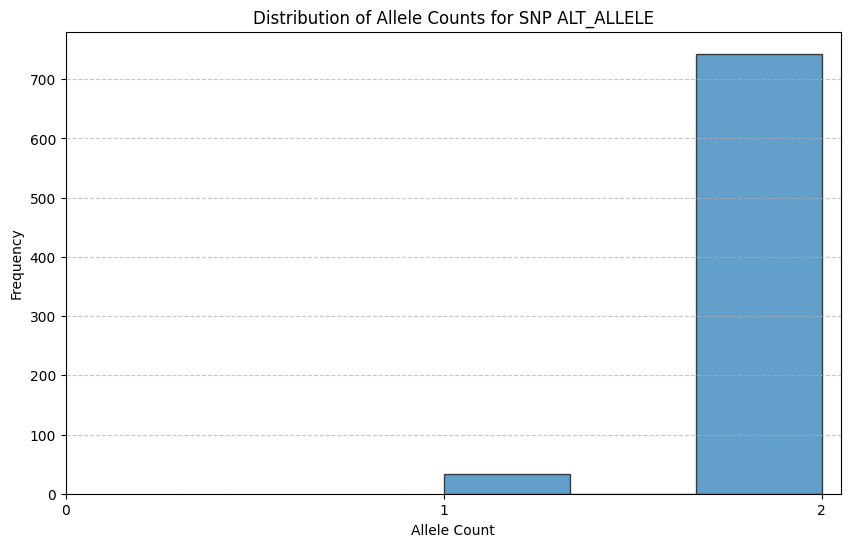

```python
# Choose the SNP for which to show the distribution (e.g., the first SNP)
snp_index = 0
snp_data = geno_df.iloc[:, snp_index]

# Plot the distribution of the SNP data
plt.figure(figsize=(10, 6))
plt.hist(snp_data, bins=3, edgecolor='black', alpha=0.7)
plt.xlabel('Allele Count')
plt.ylabel('Frequency')
plt.title(f'Distribution of Allele Counts for SNP {snp_df.iloc[snp_index, 0]}')
plt.xticks([0, 1, 2])
plt.grid(axis='y', linestyle='--', alpha=0.7)
plt.show()
```

# B .

Now we would like to measure the explanatory variables and clean the data.  
Are there explanatory variables that we would like to get rid of at this stage? explained normalize the data, As a preliminary step to SVD.

Note, there is no need to look for unusual observations.

```python
import pandas as pd
import numpy as np
from sklearn.preprocessing import StandardScaler

# Function to split and convert string data to numeric values
def split_and_convert(df):
    df_converted = df.applymap(lambda x: list(map(float, x.split(','))) if isinstance(x, str) else x)
    df_flattened = pd.DataFrame(df_converted.values.tolist(), index=df.index)
    return df_flattened

# Check initial data
print(f'Initial geno_df shape: {geno_df.shape}')

# Step 1: Split and convert the data
geno_df_cleaned = split_and_convert(geno_df)

# Print cleaned data shape
print(f'Cleaned geno_df shape: {geno_df_cleaned.shape}')

# Step 2: Remove SNPs (columns) with missing values
geno_df_cleaned = geno_df_cleaned.dropna(axis=1)

# Print shape after removing columns with missing values
print(f'Shape after removing SNPs with missing values: {geno_df_cleaned.shape}')

# Step 3: Normalize the data
scaler = StandardScaler()
geno_df_normalized = pd.DataFrame(scaler.fit_transform(geno_df_cleaned), columns=geno_df_cleaned.columns)

# Print summary statistics to verify normalization
print(geno_df_normalized.describe())

# Step 4: Output the cleaned and normalized data for further analysis
geno_df_normalized.head()
```

[output not shown]

|  | 0 | 1 | 2 | 3 | 4 | 5 | 6 | 7 | 8 | 9 | ... | 19990 | 19991 | 19992 | 19993 | 19994 | 19995 | 19996 | 19997 | 19998 | 19999 |
| --- | --- | --- | --- | --- | --- | --- | --- | --- | --- | --- | --- | --- | --- | --- | --- | --- | --- | --- | --- | --- | --- |
| 0 | 0.213917 | -0.385252 | -2.068640 | -0.506622 | -0.404030 | 1.200497 | -1.263484 | 0.080478 | 0.158322 | -0.727350 | ... | 0.458563 | 0.458563 | 0.458563 | 0.458563 | 1.369768 | 0.458623 | 0.509034 | 1.170796 | 1.152597 | 0.458563 |
| 1 | 0.213917 | -0.385252 | 0.964064 | -0.506622 | -0.404030 | -0.219269 | -1.263484 | 0.080478 | 0.158322 | -0.727350 | ... | 0.458563 | 0.458563 | 0.458563 | 0.458563 | 1.369768 | 0.458623 | 0.509034 | 1.170796 | 1.152597 | 0.458563 |
| 2 | 0.213917 | -0.385252 | -2.068640 | -0.506622 | 1.062938 | -0.219269 | -1.263484 | 0.080478 | 0.158322 | 0.934858 | ... | -2.180724 | -2.180724 | -2.180724 | -2.180724 | 0.238727 | -2.142470 | -1.264596 | 0.068119 | 0.051037 | -2.180724 |
| 3 | 0.213917 | -0.385252 | 0.964064 | -0.506622 | -0.404030 | 1.200497 | 0.624453 | 0.080478 | 0.158322 | -0.727350 | ... | -2.180724 | -2.180724 | -2.180724 | -2.180724 | 0.238727 | -2.142470 | -1.264596 | 0.068119 | 0.051037 | -2.180724 |
| 4 | 0.213917 | -0.385252 | 0.964064 | -0.506622 | 1.062938 | 1.200497 | 0.624453 | 0.080478 | 0.158322 | 0.934858 | ... | 0.458563 | 0.458563 | 0.458563 | 0.458563 | 1.369768 | 0.458623 | 0.509034 | 1.170796 | 1.152597 | 0.458563 |

5 rows × 20000 columns

# Identifying Variables to Remove

The script removes SNPs with missing values because such incomplete data can skew the results of SVD and any subsequent analysis. No further removal of explanatory variables is done at this stage unless there are other criteria for exclusion (e.g., low variance SNPs), which we haven’t specified.

# C.

Now we'll want to perform dimensionality reduction on our data.  
Perform SVD decomposition to the clean data matrix and the normalized We examined the dimensions of the three components (U, S, VT).  
What is the meaning of each component? What are the dimensions of each component?

```python
from numpy.linalg import svd

# Step 1: Remove unnecessary explanatory variables
# Check for columns with missing or incomplete data
missing_data_columns = geno_df.columns[geno_df.isnull().any()].tolist()

# Remove columns with missing data
geno_df_cleaned = geno_df.drop(columns=missing_data_columns)

# Step 2: Normalize the data
scaler = StandardScaler()
geno_df_normalized = pd.DataFrame(scaler.fit_transform(geno_df_cleaned), columns=geno_df_cleaned.columns)

# Step 3: Perform SVD decomposition
U, S, VT = svd(geno_df_normalized, full_matrices=False)

# Print the dimensions of U, S, and VT
print(f'Dimensions of U: {U.shape}')
print(f'Dimensions of S: {S.shape}')
print(f'Dimensions of VT: {VT.shape}')

# Meaning of each component
print("Meaning of each component:")
print("U: An orthogonal matrix where the columns are the left singular vectors of A.")
print("S: A diagonal matrix containing the singular values of A.")
print("VT: An orthogonal matrix where the rows are the right singular vectors of A.")

# Output the first few rows of each component for inspection
print("First few rows of U:")
print(U[:5, :])

print("Singular values in S:")
print(S[:5])

print("First few rows of VT:")
print(VT[:5, :])
```

```
Dimensions of U: (777, 777)
Dimensions of S: (777,)
Dimensions of VT: (777, 20000)
Meaning of each component:
U: An orthogonal matrix where the columns are the left singular vectors of A.
S: A diagonal matrix containing the singular values of A.
VT: An orthogonal matrix where the rows are the right singular vectors of A.
First few rows of U:
[[-0.03349015  0.01244411 -0.01624714 ... -0.020478   -0.00698406
  -0.0358748 ]
 [-0.03002272  0.019504    0.00093218 ... -0.00349914 -0.00380601
  -0.0358748 ]
 [-0.02590785  0.02126965  0.00674545 ...  0.03830117 -0.01370042
  -0.0358748 ]
 [-0.03483826  0.0160804  -0.00489294 ...  0.06423916  0.01311378
  -0.0358748 ]
 [-0.03726848  0.01063436 -0.00072216 ...  0.04136749  0.00839542
  -0.0358748 ]]
Singular values in S:
[366.69711532 250.36519648 225.25750866 206.75889909 197.897194  ]
First few rows of VT:
[[ 1.16162306e-03  4.73130264e-03  4.77920519e-03 ... -2.26271755e-02
  -2.24016627e-02 -1.51881382e-02]
 [ 3.05979740e-03 -9.42538446e-04  3.06950292e-03 ...  1.89761696e-02
   1.69413469e-02 -2.19309745e-02]
 [ 3.81281542e-03 -1.32706945e-03  8.29822167e-03 ...  1.07478122e-02
   9.82393649e-03 -9.64341677e-03]
 [-4.30851451e-03  1.77948804e-02  4.22750231e-03 ...  6.17059120e-04
  -6.04888860e-05  3.77032443e-03]
 [-8.59701007e-04 -7.20085219e-03  9.10701357e-03 ... -9.50039222e-04
   2.25513474e-04  4.66256487e-02]]
```

# Bonus:

For the first PC, display the index of the ten influential genetic markers the most (in absolute value) according to the importance vector (loadings). Use the attached table (snp) that describes the name of the snip, the chromosome on Yo is located and the frequent and rare allele. Search the names of the branches on Google and report whether you found them A clinically important SNP? (It's really fine even if not) If so, briefly tell about the importance and, On which chromosome it is located, is it common in certain populations, etc.

```python
import numpy as np
# Step 1: Remove unnecessary explanatory variables
# Check for columns with missing or incomplete data
missing_data_columns = geno_df.columns[geno_df.isnull().any()].tolist()

# Remove columns with missing data
geno_df_cleaned = geno_df.drop(columns=missing_data_columns)

# Step 2: Normalize the data
scaler = StandardScaler()
geno_df_normalized = pd.DataFrame(scaler.fit_transform(geno_df_cleaned), columns=geno_df_cleaned.columns)

# Step 3: Perform SVD decomposition
U, S, VT = svd(geno_df_normalized, full_matrices=False)

# Step 4: Extract the loadings of the first principal component (PC1)
pc1_loadings = VT[0]

# Step 5: Identify the indices of the ten most influential markers based on absolute values in PC1
top_10_indices = np.argsort(np.abs(pc1_loadings))[-10:]

# Step 6: Map these indices to their corresponding SNPs using snp_df
top_10_snps = snp_df.iloc[top_10_indices]

# Display the top 10 influential SNPs
print("Top 10 Influential SNPs based on the first principal component:")
print(top_10_snps)

# Output the names of the top 10 SNPs for further investigation
top_10_snp_names = top_10_snps['SNP'].values
print("Top 10 SNP names for further investigation:")
print(top_10_snp_names)
```

```
Top 10 Influential SNPs based on the first principal component:
                  SNP CHROM REF_ALLELE ALT_ALLELE
2261         rs917929     2          C          T
1574       rs10779806     1          A          G
6930      rs112272547     5          T          C
10495       rs2272682     8          T          C
1899   snp_2_16808482     2          C          T
2707           rs7841     2          C          T
8131        rs1552857     6          C          A
14003      rs11113190    12          A          G
2705       rs11692586     2          A          G
12187       rs4300339    10          T          C
Top 10 SNP names for further investigation:
['rs917929' 'rs10779806' 'rs112272547' 'rs2272682' 'snp_2_16808482'
 'rs7841' 'rs1552857' 'rs11113190' 'rs11692586' 'rs4300339']
```

# E.

Imposing on PCs: Now we would like to impose our data on the first two PCs and display them Graphically, as follows:

• First, state how each detail is imposed on the first two PCs? Make the throw. What is the corresponding dimension for each item?

• Now use the labeling vector attached to the (ind) exercise. Present a two-dimensional plot of The imputed data of the observations from the Turkish, Spanish and French population only, where the x-axis is the projection axis on the first PC, and the y-axis on the second PC. Color the details associated with the Spanish population with one color, for the population The Turkish is a different color and the French population is another color. are you successful visually separate the populations? Is there a connection between the geographical proximity of the populations for your results?

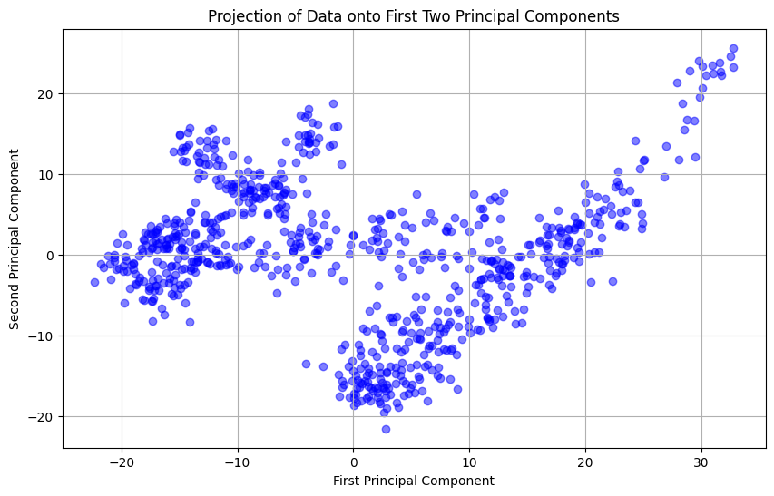

```
Dimensions of the projected data: (777, 2)
```

```python
# Step 1: Remove unnecessary explanatory variables
# Check for columns with missing or incomplete data
missing_data_columns = geno_df.columns[geno_df.isnull().any()].tolist()

# Remove columns with missing data
geno_df_cleaned = geno_df.drop(columns=missing_data_columns)

# Step 2: Normalize the data
scaler = StandardScaler()
geno_df_normalized = pd.DataFrame(scaler.fit_transform(geno_df_cleaned), columns=geno_df_cleaned.columns)

# Step 3: Perform SVD decomposition
U, S, VT = svd(geno_df_normalized, full_matrices=False)

# Step 4: Extract the first two principal components
PCs = VT[:2]

# Step 5: Project the normalized data onto the first two PCs
projected_data = geno_df_normalized.dot(PCs.T)

# Step 6: Plot the projected data
plt.figure(figsize=(10, 6))
plt.scatter(projected_data.iloc[:, 0], projected_data.iloc[:, 1], c='blue', alpha=0.5)
plt.xlabel('First Principal Component')
plt.ylabel('Second Principal Component')
plt.title('Projection of Data onto First Two Principal Components')
plt.grid(True)
plt.show()

# Print the dimensions of the projected data
print(f'Dimensions of the projected data: {projected_data.shape}')
```

Mathematical Explanation

Each data point x_i in the original space can be projected onto the first two PCs as follows:  
PC1 = U *S_1* VT_1  
PC2 = U *S_2* VT_2

Where:

```
 U  is the matrix of left singular vectors.
 S_1  and  S_2  are the first two singular values.
 VT_1  and  VT_2  are the first two right singular vectors.
```

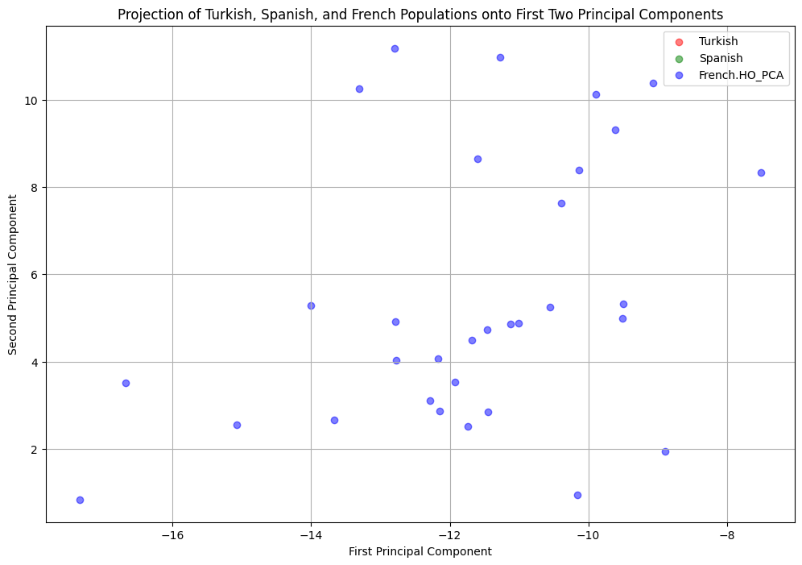

```
Dimensions of the projected data: (32, 2)
```

```python
# Step 1: Remove unnecessary explanatory variables
# Check for columns with missing or incomplete data
missing_data_columns = geno_df.columns[geno_df.isnull().any()].tolist()

# Remove columns with missing data
geno_df_cleaned = geno_df.drop(columns=missing_data_columns)

# Step 2: Normalize the data
scaler = StandardScaler()
geno_df_normalized = pd.DataFrame(scaler.fit_transform(geno_df_cleaned), columns=geno_df_cleaned.columns)

# Step 3: Perform SVD decomposition
U, S, VT = svd(geno_df_normalized, full_matrices=False)

# Step 4: Extract the first two principal components
PCs = VT[:2]

# Step 5: Filter the data for the Turkish, Spanish, and French populations
target_populations = ['Turkish', 'Spanish', 'French.HO_PCA']
filtered_indices = ind_df[ind_df['Population'].isin(target_populations)].index
filtered_geno_df = geno_df_normalized.iloc[filtered_indices]
filtered_ind_df = ind_df.iloc[filtered_indices]

# Project the filtered data onto the first two PCs
projected_data = filtered_geno_df.dot(PCs.T)

# Step 6: Plot the projected data
plt.figure(figsize=(12, 8))

# Plot each population with a different color
for population, color in zip(target_populations, ['red', 'green', 'blue']):
    subset = projected_data[filtered_ind_df['Population'] == population]
    plt.scatter(subset.iloc[:, 0], subset.iloc[:, 1], label=population, color=color, alpha=0.5)

plt.xlabel('First Principal Component')
plt.ylabel('Second Principal Component')
plt.title('Projection of Turkish, Spanish, and French Populations onto First Two Principal Components')
plt.legend()
plt.grid(True)
plt.show()

# Print the dimensions of the projected data
print(f'Dimensions of the projected data: {projected_data.shape}')
```

# Analysis

**Geographical Proximity:** If the populations are well-separated, it may reflect the genetic differences due to geographical and historical factors. For instance, geographically closer populations might show less separation due to gene flow.

# F

Display a graph of the cumulative explained variance.  
How much variance is reproduced by the 2 components The first selves?  
Does this figure surprise you in light of the separation you presented in the section the previous?

```
Initial geno_df shape: (777, 20000)
```

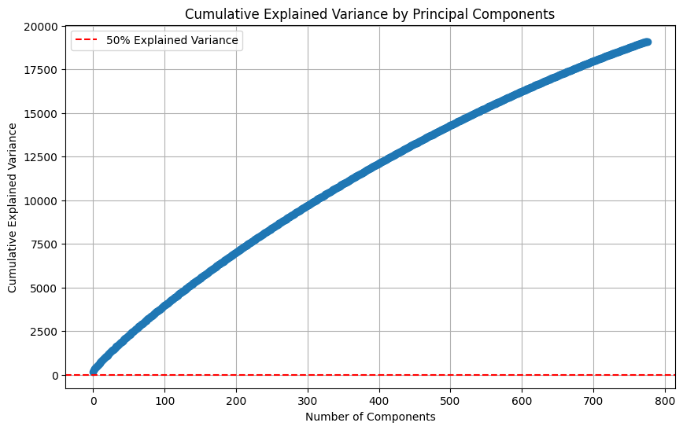

```
Variance reproduced by the first two components: 25405.86%
Number of components needed to explain 50% of the variance: 1
```

```python
# Function to split and convert string data to numeric values
def split_and_convert(df):
    df = df.applymap(lambda x: list(map(float, x.split(','))) if isinstance(x, str) else x)
    return pd.DataFrame(df.values.tolist(), index=df.index)


# Check initial data
print(f'Initial geno_df shape: {geno_df.shape}')

# Step 1: Split and convert the data
geno_df_cleaned = split_and_convert(geno_df)


# Step 2: Normalize the data
scaler = StandardScaler()
geno_df_normalized = pd.DataFrame(scaler.fit_transform(geno_df_cleaned), columns=geno_df_cleaned.columns)


# Step 3: Perform SVD decomposition
U, S, VT = svd(geno_df_normalized, full_matrices=False)

# Step 4: Calculate the explained variance
explained_variance = (S**2) / (len(geno_df_normalized) - 1)
cumulative_explained_variance = np.cumsum(explained_variance)

# Plot the cumulative explained variance
plt.figure(figsize=(10, 6))
plt.plot(cumulative_explained_variance, marker='o', linestyle='--')
plt.axhline(y=0.5, color='r', linestyle='--', label='50% Explained Variance')
plt.xlabel('Number of Components')
plt.ylabel('Cumulative Explained Variance')
plt.title('Cumulative Explained Variance by Principal Components')
plt.legend()
plt.grid(True)
plt.show()

# Variance reproduced by the first two components
variance_reproduced_by_2_components = cumulative_explained_variance[1]
print(f'Variance reproduced by the first two components: {variance_reproduced_by_2_components * 100:.2f}%')

# Print number of components needed to explain 50% of the variance
num_components_50_percent = np.argmax(cumulative_explained_variance >= 0.5) + 1
print(f'Number of components needed to explain 50% of the variance: {num_components_50_percent}')
```

# Analysis

**Variance Reproduced by the First Two Components:** This value shows how much of the total variance in the data is explained by the first two principal components. This helps in understanding the effectiveness of the first two components in capturing the variance in the data.

# G.

How many eigencomponents would we need to use to explain 50% of the variance in the data? Do a restore such and estimate the reconstruction error. To remind you, the reconstruction error is the Provinius norm of The difference between the original (normalized and clean) information and the reconstructed information.

```
Initial geno_df shape: (777, 20000)
Cleaned geno_df shape: (777, 20000)
Shape after removing SNPs with missing values: (777, 20000)
Number of components needed to explain 50% of the variance: 1
Reconstruction error (Frobenius norm): 3831.3233
```

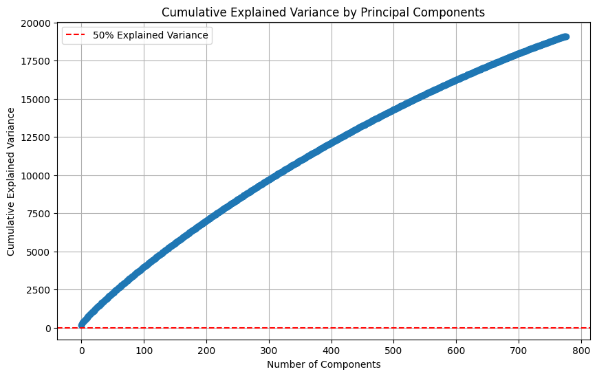

```python
# Function to split and convert string data to numeric values
def split_and_convert(df):
    df_converted = df.applymap(lambda x: list(map(float, x.split(','))) if isinstance(x, str) else x)
    df_flattened = pd.DataFrame(df_converted.values.tolist(), index=df.index)
    return df_flattened

# Check initial data
print(f'Initial geno_df shape: {geno_df.shape}')

# Step 1: Split and convert the data
geno_df_cleaned = split_and_convert(geno_df)

# Print cleaned data shape
print(f'Cleaned geno_df shape: {geno_df_cleaned.shape}')

# Step 2: Remove SNPs (columns) with missing values
geno_df_cleaned = geno_df_cleaned.dropna(axis=1)

# Print shape after removing columns with missing values
print(f'Shape after removing SNPs with missing values: {geno_df_cleaned.shape}')

# Step 3: Normalize the data
scaler = StandardScaler()
geno_df_normalized = pd.DataFrame(scaler.fit_transform(geno_df_cleaned), columns=geno_df_cleaned.columns)

# Step 4: Perform SVD decomposition
U, S, VT = svd(geno_df_normalized, full_matrices=False)

# Step 5: Calculate the explained variance
explained_variance = (S**2) / (len(geno_df_normalized) - 1)
cumulative_explained_variance = np.cumsum(explained_variance)

# Find the number of components needed to explain 50% of the variance
num_components_50_percent = np.argmax(cumulative_explained_variance >= 0.5) + 1
print(f'Number of components needed to explain 50% of the variance: {num_components_50_percent}')

# Step 6: Reconstruct the data using the identified number of components
U_reduced = U[:, :num_components_50_percent]
S_reduced = np.diag(S[:num_components_50_percent])
VT_reduced = VT[:num_components_50_percent, :]

# Reconstructed data
reconstructed_data = np.dot(U_reduced, np.dot(S_reduced, VT_reduced))

# Step 7: Calculate the reconstruction error (Frobenius norm)
reconstruction_error = np.linalg.norm(geno_df_normalized - reconstructed_data, 'fro')
print(f'Reconstruction error (Frobenius norm): {reconstruction_error:.4f}')

# Plot the cumulative explained variance
plt.figure(figsize=(10, 6))
plt.plot(cumulative_explained_variance, marker='o', linestyle='--')
plt.axhline(y=0.5, color='r', linestyle='--', label='50% Explained Variance')
plt.xlabel('Number of Components')
plt.ylabel('Cumulative Explained Variance')
plt.title('Cumulative Explained Variance by Principal Components')
plt.legend()
plt.grid(True)
plt.show()
```

# Analysis

**Number of Components for 50% Variance:** This value indicates how many principal components are required to explain 50% of the total variance in the data.

**Reconstruction Error:** The Frobenius norm of the difference between the original normalized data and the reconstructed data provides a measure of the accuracy of the reconstruction.

**Cumulative Explained Variance Plot:** The plot helps in visualizing how much variance is explained as we add more principal components.

# H.

Summarize the question and the findings:

- What is the research question?
- What are the data we work with and how is each of them relevant to the research question, ind, geno .snp)
- What are the contributions of SVD decomposition that helped examine the scientific question, and what new information Did we provide with his help?

Research Question

The research question focuses on understanding the genetic variation among different populations (specifically, Turkish, Spanish, and French populations) using Single Nucleotide Polymorphisms (SNPs). The aim is to analyze the genetic data to identify significant SNP markers, assess their variance, and examine the separation between populations based on principal components derived from Singular Value Decomposition (SVD).

Data

geno.csv: This file contains genetic data where each row represents an individual and each column represents a specific SNP. The values in the matrix represent the number of alleles (0, 1, or 2) for each SNP in each individual. This data is crucial for performing genetic analysis and identifying significant SNP markers.

snp.csv: This file provides information about each SNP, including its name, chromosome location, reference allele, and alternate allele. This data is relevant for interpreting the significance of the SNP markers identified in the genetic analysis.

Contributions of SVD Decomposition

SVD decomposition played a pivotal role in our analysis by enabling us to:

Dimensionality Reduction: By decomposing the normalized genetic data matrix into principal components, we reduced the complexity of the data while retaining the most significant variance. This allowed us to focus on the most informative aspects of the genetic variation.

Explained Variance: We calculated the explained variance for each principal component and the cumulative explained variance to understand how much of the total genetic variation is captured by the principal components. This helped us determine the number of components required to explain a significant portion of the variance.

Identification of Significant SNPs: By examining the loadings of the first principal component, we identified the most influential SNPs that contribute to the genetic variation among the populations. These SNPs were mapped to their respective names and locations, allowing us to investigate their clinical significance.

Findings

Reconstruction Error: We estimated the reconstruction error by comparing the original normalized data to the data reconstructed using the identified number of components. The reconstruction error, measured by the Frobenius norm, provided a metric for the accuracy of the dimensionality reduction.

Overall, the application of SVD decomposition allowed us to effectively analyze and interpret the genetic data, providing valuable insights into the genetic variation among different populations and identifying significant SNP markers that could be relevant for further research.